# Trayectoria COVID-19 del Condado Miami-Dade

Roy Williams, Gabriel J. Odom, Zoran Bursac, and Mary Jo Trepka

14 June 2020

# Introducción

El conocimiento del público acerca de temas cientificos es crítico en tiempos de crisis. Este análisis fué desarrollado para examinar la trayectória de COVID-19 en el condado de Miami-Dade. Para la apertura escalonado, la Casa Blanca ha establecido una directriz para los municípios locales en un reporte titulado “Opening Up America Again.” En este reporte, está sugerido que:

1. Areas locales demuestren una trayectória descendente en números de casos positivos como un porcentaje de exámenes totales sobre un periodo de dos semanas, y
2. Capacidad de los hospitales locales de encargarse de todos los pacientes sin cuidado de crisis.

El analisis comienza examinando el número de nuevos casos positivos cada día, y el número de exámenes totales ejecutados cada día. Las figuras están presentadas juntas porque **mientras hayan mas exámenes, es probable que hayan mas resultados positivos de exámenes.** Por lo tanto, la proporción de casos positivos también están calculados. Dado que el número de exámenes conducidos sea plano o estén subiendo, **la proporción de casos positivos es la métrica clave usada las trayectórias de las epidémias.** Es recomendado que esta proporción no exceda el 5%.

Finalmente, para asegurar que los hospitales puedan satisfacer la demanda sin cuidado de crisis, el censo de hospitalización de casos positivos de COVID-19, el censo de casos positivos de COVID-19 en Unidad de Cuidados Intensivos, y el censo de ventilación de casos positivos de COVID-19 está tramado sobre el tiempo. Censo se refiere al número de pacientes positivos de COVID-19 en el hospital, Unidad de Cuidado Intensivos, y usando ventiladores médicos, respectivamente, en un día determinado.

# COVID-19 Test Counts and Proportions

## Datos Completos

Esta es una tabla de los datos más recientes que tenemos disponibles. Incluimos fuentes de datos al final del documento.

| Fecha | Positivo | Negativo | Proporción positiva |
| --- | --- | --- | --- |
| 2-Apr | 544 | 2413 | 18.3970240 |
| 3-Apr | 625 | 1878 | 24.9700360 |
| 4-Apr | 531 | 2521 | 17.3984273 |
| 5-Apr | 311 | 1260 | 19.7963081 |
| 6-Apr | 556 | 2309 | 19.4066318 |
| 7-Apr | 493 | 1990 | 19.8550141 |
| 8-Apr | 488 | 1113 | 30.4809494 |
| 9-Apr | 435 | 2636 | 14.1647672 |
| 10-Apr | 542 | 2505 | 17.7879882 |
| 11-Apr | 563 | 2732 | 17.0864947 |
| 12-Apr | 364 | 1614 | 18.4024267 |
| 13-Apr | 477 | 2267 | 17.3833819 |
| 14-Apr | 364 | 1663 | 17.9575728 |
| 15-Apr | 438 | 2392 | 15.4770318 |
| 16-Apr | 536 | 2767 | 16.2276718 |
| 17-Apr | 519 | 2901 | 15.1754386 |
| 18-Apr | 296 | 1509 | 16.3988920 |
| 19-Apr | 465 | 2690 | 14.7385103 |
| 20-Apr | 413 | 3232 | 11.3305899 |
| 21-Apr | 577 | 4230 | 12.0033285 |
| 22-Apr | 465 | 2701 | 14.6873026 |
| 23-Apr | 619 | 3647 | 14.5100797 |
| 24-Apr | 552 | 2852 | 16.2162162 |
| 25-Apr | 564 | 4136 | 12.0000000 |
| 26-Apr | 384 | 2576 | 12.9729730 |
| 27-Apr | 446 | 2789 | 13.7867079 |
| 28-Apr | 213 | 1333 | 13.7774903 |
| 29-Apr | 309 | 1704 | 15.3502236 |
| 30-Apr | 333 | 3724 | 8.2080355 |
| 1-May | 250 | 3616 | 6.4666322 |
| 2-May | 144 | 2183 | 6.1882252 |
| 3-May | 295 | 2896 | 9.2447509 |
| 4-May | 151 | 3900 | 3.7274747 |
| 5-May | 165 | 2231 | 6.8864775 |
| 6-May | 153 | 2296 | 6.2474479 |
| 7-May | 95 | 2091 | 4.3458371 |
| 8-May | 165 | 2615 | 5.9352518 |
| 9-May | 225 | 2208 | 9.2478422 |
| 10-May | 159 | 2546 | 5.8780037 |
| 11-May | 164 | 3420 | 4.5758929 |
| 12-May | 153 | 1660 | 8.4390513 |
| 13-May | 274 | 2214 | 11.0128617 |
| 14-May | 213 | 1726 | 10.9850438 |
| 15-May | 177 | 1927 | 8.4125475 |
| 16-May | 544 | 3047 | 15.1489836 |
| 17-May | 164 | 4218 | 3.7425833 |
| 18-May | 123 | 5310 | 2.2639426 |
| 19-May | 66 | 13671 | 0.4804542 |
| 20-May | 343 | 7304 | 4.4854191 |
| 21-May | 190 | 2649 | 6.6924974 |
| 22-May | 158 | 3143 | 4.7864284 |
| 23-May | 123 | 2491 | 4.7054323 |
| 24-May | 219 | 5545 | 3.7994448 |
| 25-May | 113 | 2819 | 3.8540246 |
| 26-May | 100 | 1786 | 5.3022269 |
| 27-May | 143 | 2693 | 5.0423131 |
| 28-May | 259 | 5673 | 4.3661497 |
| 29-May | 165 | 2458 | 6.2905071 |
| 30-May | 202 | 4115 | 4.6791754 |
| 31-May | 138 | 2921 | 4.5112782 |
| 1-Jun | 83 | 1042 | 7.3777778 |
| 2-Jun | 250 | 4639 | 5.1135201 |
| 3-Jun | 274 | 4952 | 5.2430157 |
| 4-Jun | 217 | 3909 | 5.2593311 |
| 5-Jun | 233 | 3111 | 6.9677033 |
| 6-Jun | 328 | 8882 | 3.5613464 |
| 7-Jun | 227 | 2695 | 7.7686516 |
| 8-Jun | 231 | 4264 | 5.1390434 |
| 9-Jun | 250 | 3379 | 6.8889501 |
| 10-Jun | 300 | 4977 | 5.6850483 |
| 11-Jun | 258 | 4218 | 5.7640751 |
| 12-Jun | 571 | 4915 | 10.4083121 |
| 13-Jun | 329 | 9426 | 3.3726294 |

Los datos anteriores muestran para cada día desde el 2 de abril: la cantidad de pruebas COVID-19 positivas, la cantidad de pruebas COVID-19 negativas y la proporción de pruebas COVID-19 positivas con respecto a las pruebas COVID-19 totales.

## Total de pruebas COVID-19 por día

Vemos el siguiente patrón para el recuento de las pruebas totales en los últimos dos meses (se muestra en una escala logarítmica)

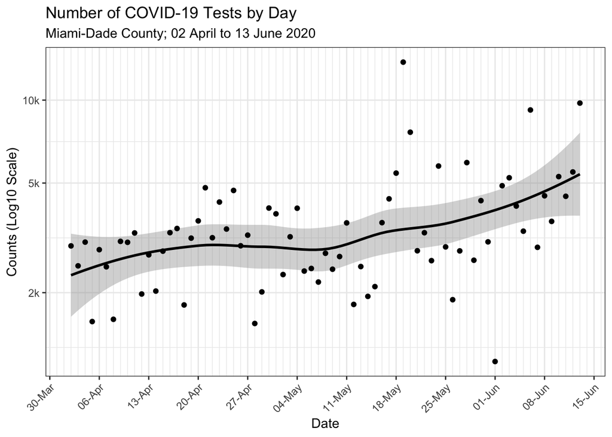

El numero promedio de exámenes de COVID-19 realizados cada dia ha subido de 2,000 al principio de Abril hasta mas de 4,500 a mediados de Junio. Estos datos están presentado en una escala logarítmica.

## Pruebas positivas de COVID-19 por día

Vemos el siguiente patrón para el recuento de pruebas positivas en los últimos dos meses:

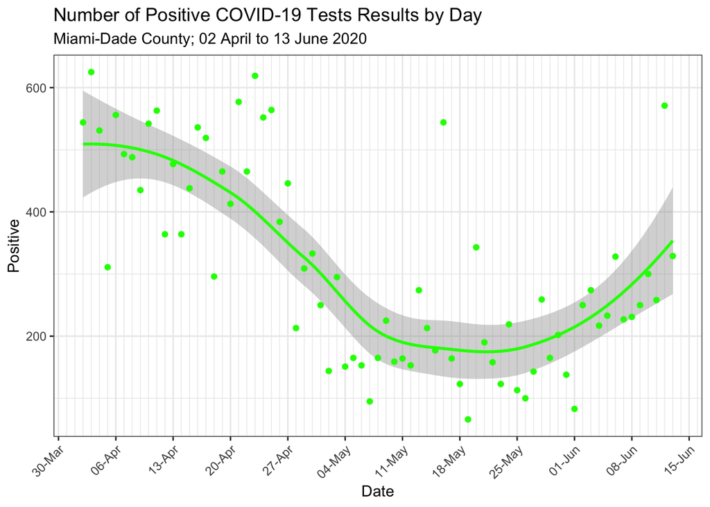

Hubo una disminución general en el número de resultados positivos de exámenes desde el principio de Abril hasta alrededor del 11 de Mayo. Luego esta tendencia se aplano, y después aumento.

## Proporción de Resultados Positivos de todos los Exámenes entre las últimas Dos Semanas en el Condado de Miami-Dade

Proporción de Resultados Positivos de todos los Exámenes entre las últimas Dos Semanas en el Condado de Miami-Dade

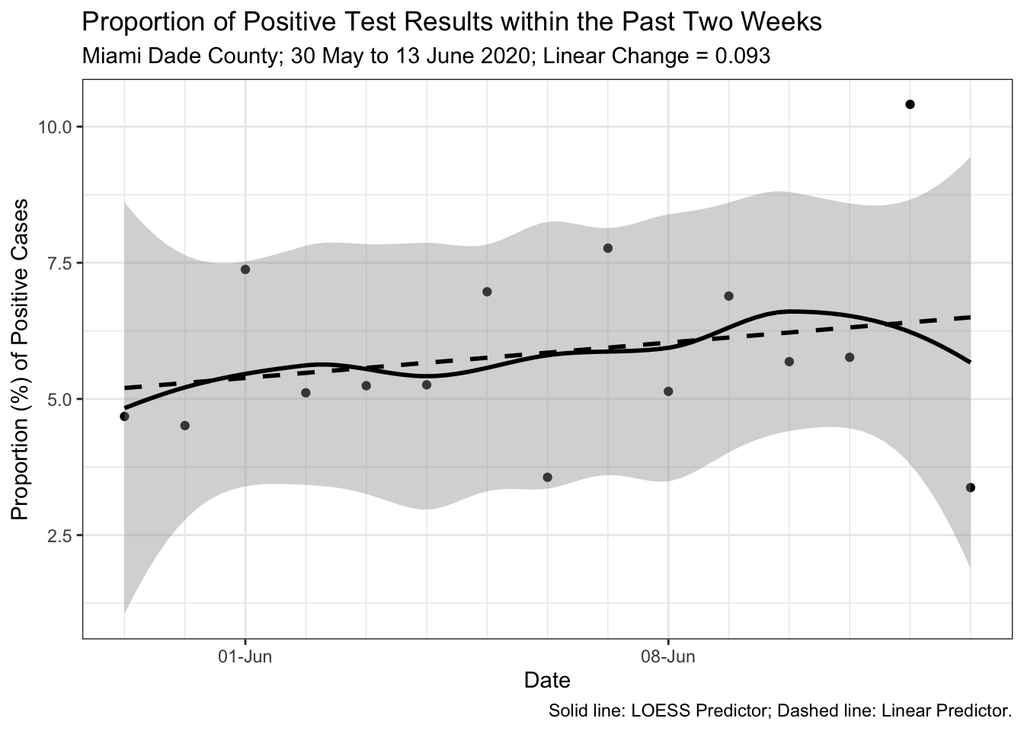

## Proporción de pruebas COVID-19 positivas por día

Estas son las proporciones de las pruebas COVID-19 positivas para el condado de Miami-Dade desde principios de abril:

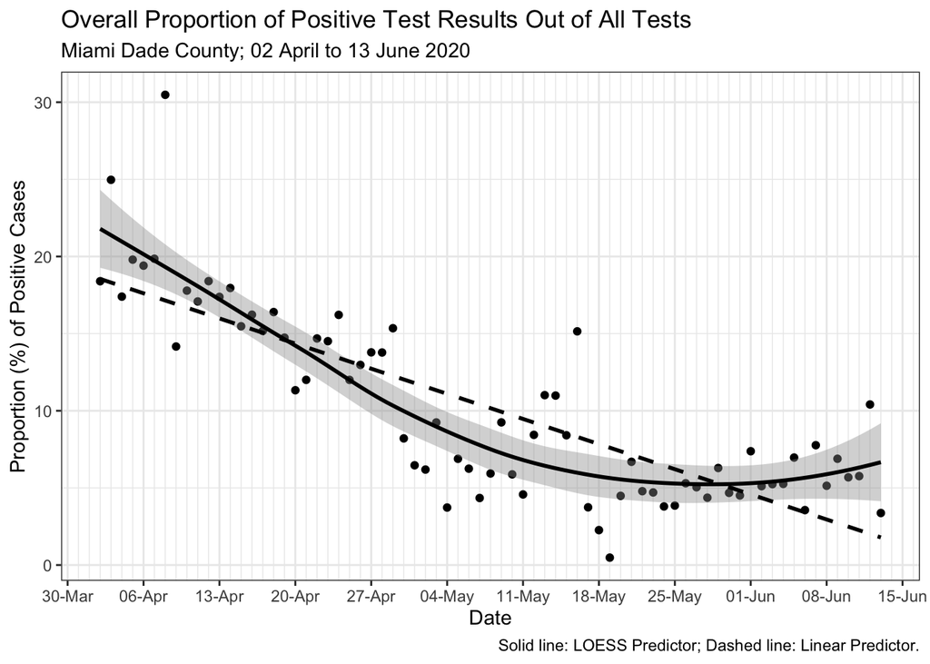

En general, la proporción de resultados positivos de exámenes ha **disminuido significativamente** desde el 20% en Abril hasta la proporción corriente de aproximadamente 5%. Esto es la función de la disponibilidad de exámenes y la población que está tomando el exámen. En general, desde la reapertura del condado, la proporción de exámenes positivos ya no está disminuyendo sobre el tiempo.

# Datos de Hospitalización

## Datos Completos

| Fecha | Hospitalizado | ICU | Ventilados | Admitido el Día Anterior | Dado de Alta el Día Anterior | Cambio de Admisión |
| --- | --- | --- | --- | --- | --- | --- |
| 2020-04-02 | 320 | 130 | 116 | NA | NA | NA |
| 2020-04-03 | 346 | 133 | 116 | 111 | 33 | 78 |
| 2020-04-04 | 416 | 133 | 112 | 59 | 37 | 22 |
| 2020-04-05 | 533 | 188 | 146 | 108 | 19 | 89 |
| 2020-04-06 | 516 | 178 | 151 | 89 | 21 | 68 |
| 2020-04-07 | 591 | 199 | 167 | 76 | 28 | 48 |
| 2020-04-08 | 636 | 215 | 166 | 107 | 32 | 75 |
| 2020-04-09 | 634 | 232 | 170 | 99 | 61 | 38 |
| 2020-04-10 | 681 | 245 | 172 | 79 | 37 | 42 |
| 2020-04-10 | 676 | 251 | 183 | 73 | 36 | 37 |
| 2020-04-11 | 671 | 238 | 177 | 99 | 64 | 35 |
| 2020-04-12 | 672 | 243 | 192 | 80 | 59 | 21 |
| 2020-04-12 | 714 | 245 | 183 | 60 | 61 | -1 |
| 2020-04-13 | 653 | 247 | 184 | 74 | 47 | 27 |
| 2020-04-13 | 695 | 251 | 184 | 80 | 48 | 32 |
| 2020-04-14 | 653 | 204 | 146 | 69 | 41 | 28 |
| 2020-04-14 | 712 | 249 | 174 | 86 | 66 | 20 |
| 2020-04-15 | 693 | 234 | 169 | 84 | 76 | 8 |
| 2020-04-16 | 714 | 223 | 176 | 77 | 84 | -7 |
| 2020-04-16 | 736 | 226 | 176 | 74 | 111 | -37 |
| 2020-04-17 | 706 | 213 | 172 | 83 | 107 | -24 |
| 2020-04-17 | 797 | 285 | 170 | 74 | 88 | -14 |
| 2020-04-18 | 697 | 221 | 170 | 101 | 137 | -36 |
| 2020-04-18 | 697 | 219 | 170 | 93 | 138 | -45 |
| 2020-04-19 | 730 | 223 | 170 | 71 | 105 | -34 |
| 2020-04-20 | 727 | 210 | 167 | 58 | 64 | -6 |
| 2020-04-21 | 759 | 205 | 155 | 92 | 81 | 11 |
| 2020-04-22 | 743 | 196 | 148 | 72 | 88 | -16 |
| 2020-04-22 | 722 | 194 | 139 | 71 | 121 | -50 |
| 2020-04-23 | 706 | 186 | 129 | 91 | 62 | 29 |

[output cut: 61 more lines]

Los datos anteriores son datos del censo hospitalario COVID-19 en el condado de Miami-Dade para todas las fechas con datos disponibles desde el 2 de abril. Estas columnas son: el número de pacientes hospitalizados con COVID-19 ( **Hospitalizados** ), el número de pacientes en cuidados intensivos con COVID-19 ( **UCI** ), el número de pacientes en cuidados intensivos con COVID-19 que también están en ventiladores ( **Ventilados** ), el número de pacientes positivos para COVID-19 que ingresaron el día anterior ( **Admitido el día anterior**), el número de pacientes recuperados de COVID-19 que fueron dados de alta el día anterior ( **Dado de Alta el Día Anterior** ), y la admisión neta de pacientes positivos para COVID-19 el día anterior (**Cambio de Admisión**); un valor negativo significa que más pacientes recuperados fueron dados de alta que pacientes enfermos admitidos). *Hay un error de datos para el recuento ventilado el 4 de Junio. Eliminamos este punto de los datos antes de estimar los modelos que se muestran a continuación.*

## Hosptial COVID-19 Census

Ahora mostramos una gráfica censal de hospitalizaciones, pacientes en UCI y aquellos en UCI con ventiladores (mostrados en una escala logarítmica):

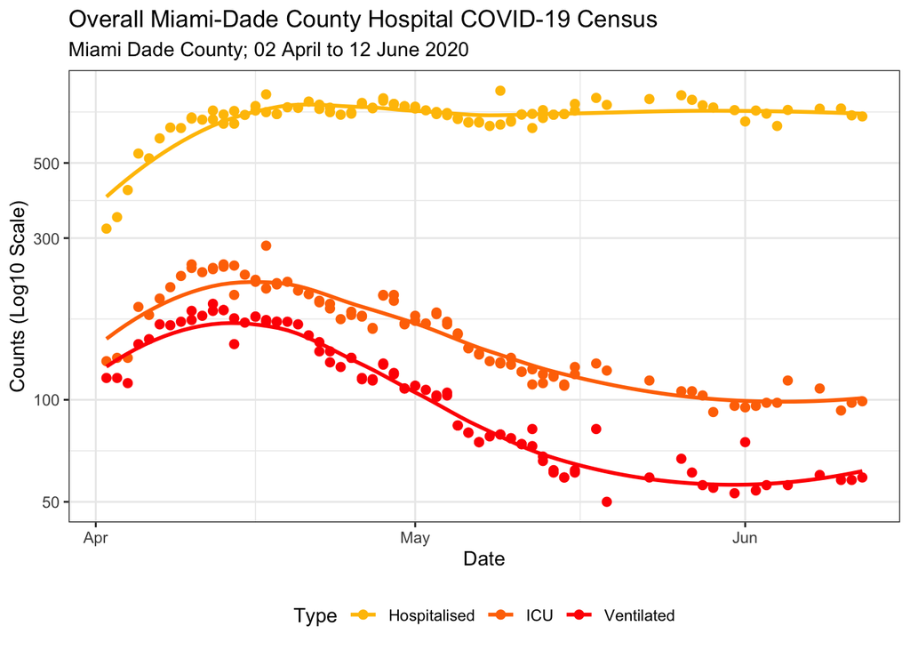

# Conclusión

# Origen de los datos

Las fuentes de datos son las siguientes:

- **Resultados de la prueba COVID-19**: La cantidad de resultados positivos y negativos de la prueba COVID-19 provienen del Departamento de Salud de Florida: https://floridahealthcovid19.gov/.
- **Censo Hospitalario COVID-19**: Los datos de hospitalización son difundidos por la Agencia de Administración de Atención Médica de Florida: https://ahca.myflorida.com/.

# Agradecimientos

Traducción cortesía de Mateo Alvarez, Alberto Cruz, y Roy Williams.

[GitHub](https://github.com/Rwilli5/MiamiCovidProject/)